# Milestone Report

Leena Dhande

January 14, 2018

## Summary

The Capstone project for the Coursera Data Science Specialization involves using the HC Corpora Dataset. The Capstone project is done in collaboration with Swiftkey and the goal of this project is to design a shiny application with text prediction capabilities. This report will outline the exploratory analysis of the dataset and the current plans for implementing the text prediction algorithm.

## Description of Data

We need to download the source data from http://d396qusza40orc.cloudfront.net/dsscapstone/dataset/Coursera-SwiftKey.zip. The HC Corpora dataset is comprised of the output of crawls of news sites, blogs and twitter. The dataset contains 3 files across four languages (Russian, Finnish, German and English). This project will focus on the English language datasets. The names of the data files are as follows:

1. en_US.blogs.txt
2. en_US.twitter.txt
3. en_US.news.txt

The datasets will be referred to as “Blogs”, “Twitter” and “News” for the remainder of this report.

## Download the data

```r
if(!file.exists("Coursera-SwiftKey.zip")){
    #Download the dataset
    download.file("https://d396qusza40orc.cloudfront.net/dsscapstone/dataset/Coursera-SwiftKey.zip",
                  "Coursera-SwiftKey.zip")
    Download_Date <- Sys.time()
    Download_Date

    #Unzip the dataset
    unzip("Coursera-SwiftKey.zip")
}
```

## Data Analysis

Below, is a summary of the 3 corpus documents.

```
##     Files   Lines Longest_Line Words... File_Size_Mb
## 1   Blogs  899288        40835 37334441       200.42
## 2    News   77259         5760  2643972       196.28
## 3 Twitter 2360148          213 30373832       159.36
```

## Sampling

Due to the large size of these files, processing the entire contents on a local computer proved to be very time consuming. So, I chose to sample the data in order to move forward as quickly as possible. For each individual corpus, I chose to randomly sample 40% (configurable) of the document prior to performing exploratory analysis. After performing exploratory analysis on each individual corpus, I chose to set a sampling percentage of 10% (configurable) for each file and combined them into a single file. The code below is how this was accomplished for the full sample:

```r
set.seed(892)
sample_pct <- .1
blogs_data_sample <- blogs_data[sample(1:blogs_lines, blogs_lines*sample_pct)]
news_data_sample <- news_data[sample(1:news_lines, news_lines*sample_pct)]
twitter_data_sample <- twitter_data[sample(1:twitter_lines, twitter_lines*sample_pct)]
sample_data <- list(blogs_data_sample, news_data_sample, twitter_data_sample)
```

## Common Words

Words were independently analyzed in each of the corpus files (at the higher sample rate of 40%). Subsequently all files were combined and analyzed (at a lower sample rate of 10%). The most frequent words varied per corpus, however, the words “will”, “just”, and “can” made the top 10 in all 3 documents. The barplot below show the details.

## Blogs Data File

Below is a summary of the most frequent words based on the blogs sampled data:

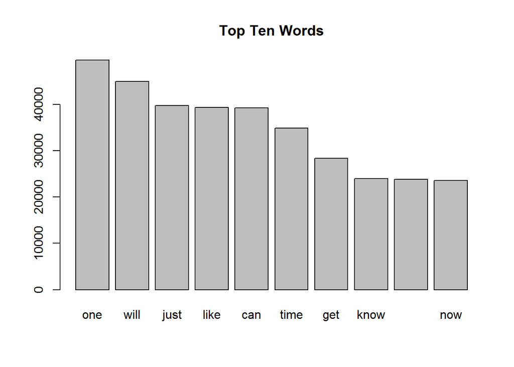

## News Data File

Below is a summary of the most frequent words bases on the news sampled data:

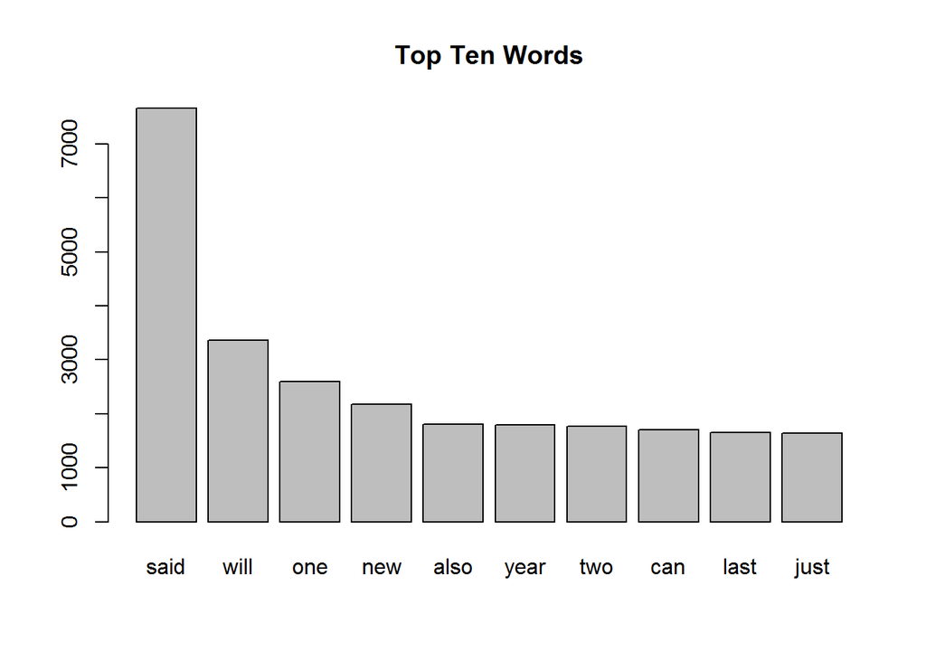

## Twitter Data File

Below is a summary of the most frequent words based on the twitter sampled data:

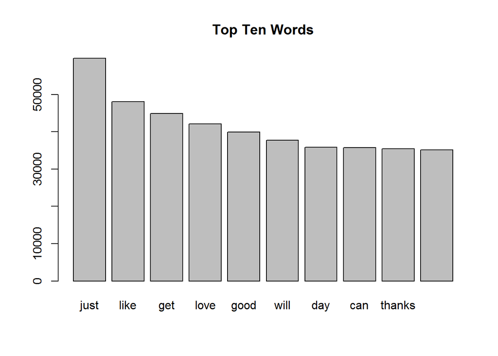

## Full Data

Below is a summary of the most frequent words base on the full sampled data:

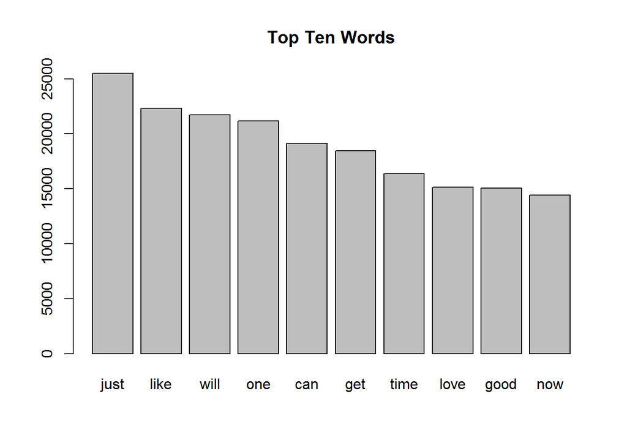

## Next steps

Need to develop a Shiny application that can predict the next word in a phrase.We will build an n-gram algorithm based on the above analysis for predicting the next word from the previous one, two, or three words